# Fit linear model in R

# 1 Packages

```r
library(minqa)
library(RcppDE)
library(ggplot2)
library(broom)

a <- config::get()
```

# 2 Linear Model in R

Here is a super-simple data set for fitting a linear model

The data

```r
data <- readRDS(a$linear_data)

head(data)
```

```
.          x        y
. 1 27.12759 22.98670
. 2 91.97554 59.42834
. 3 30.49445 19.89885
. 4 84.24914 57.78417
. 5 92.40184 61.17431
. 6 55.46875 34.40518
```

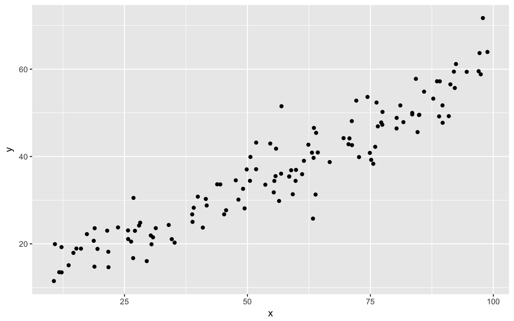

```r
qplot(data=data,x,y, geom="point")
```

## 2.1 Simple linear regression using `lm`

The `lm` function is the “right” way to fit this data.  
It is easy to do and you get a nice presentation of the estimation results.

```r
fit <- lm(y~x, data)
```

```r
fitt <- lm(y~x, data)
```

When we call `lm`, the following statistical model is assumed:

$y_i = mx_i + b + \varepsilon_{i}$

and our mean function is

$E(y|x) = mx + b$

So this is a “simple” linear model and the mean function provides the predictions when we know the predictor (`x`) and parameters (`m` and `b`).

Checking the results:

```r
fitt
```

```
.
. Call:
. lm(formula = y ~ x, data = data)
.
. Coefficients:
. (Intercept)            x
.      8.0730       0.5127
```

```r
tidy(fitt)
```

```
.          term  estimate  std.error statistic      p.value
. 1 (Intercept) 8.0730288 0.97698104   8.26324 1.905754e-13
. 2           x 0.5126619 0.01593627  32.16951 9.862668e-62
```

Since the data and the model are so simple, lets use this example to explore other optimizers that are available in `R`. Hopefully, the simplicity of the data and model will allow us to focus more on what the optimizer is doing. Once we understand how the optimizer is working, we will be better equipped to look at optimization problems for ODE-based models and more complicated data sets.

# 3 Fit with `stats::optim`

Create a function that calculate predicted values

The function arguments are:

- `p` the parameters proposed by the optimizer
- `data` we’ll pass this in as an “optional” argument; we’ll use this to get at the observed values

The function generates predicted values for all of the observed values and returns the sum of squared residuals:

```r
linear_ols <- function(p, data) {

  y.hat <- p[1] + p[2]*data$x

  sum((y.hat - data$y)^2)
}
```

When the optimizer works with this function, it will search the parameter space to minimize the sum of squared residuals.

We must supply initial estimates

```r
theta <- c(beta0 = 10, beta1 = 10)
```

We can find the minimum of this function by using `stats::optim`

```r
fit <- optim(theta,linear_ols,data=data)

fit
```

```
. $par
.     beta0     beta1
. 8.0789055 0.5136089
.
. $value
. [1] 2495.462
.
. $counts
. function gradient
.       59       NA
.
. $convergence
. [1] 0
.
. $message
. NULL
```

```r
fit$par
```

```
.     beta0     beta1
. 8.0789055 0.5136089
```

```r
coef(fitt)
```

```
. (Intercept)           x
.   8.0730288   0.5126619
```

## 3.1 Fit with alternate optimizer

By default, `stats::optim` uses a Nelder-Mead optimization engine. But there are several options for us to choose from.

This example shows how to solve the same problem, but with a simulated annealing algorithm. The setup is the same, but we choose `method="SANN"`

```r
set.seed(22020)

fit <- optim(theta, linear_ols, data=data, method="SANN")

fit
```

```
. $par
.     beta0     beta1
. 8.0782689 0.5126117
.
. $value
. [1] 2494.959
.
. $counts
. function gradient
.    10000       NA
.
. $convergence
. [1] 0
.
. $message
. NULL
```

```r
fit$par
```

```
.     beta0     beta1
. 8.0782689 0.5126117
```

```r
coef(fitt)
```

```
. (Intercept)           x
.   8.0730288   0.5126619
```

## 3.2 Derivative-free optimization with `minqa`

The other optimizer we like to use is `minqa::newuoa`. The setup is exactly the same as the one we used for `stats::optim`

```r
fit <- newuoa(theta, linear_ols, data=data)
fit
```

```
. parameter estimates: 8.07302883607009, 0.512661869849059
. objective: 2494.95826870569
. number of function evaluations: 84
```

and we get about the same answer

```r
fit$par
```

```
. [1] 8.0730288 0.5126619
```

## 3.3 Global search with `RcppDE`

Both `DEoptim` and `RcppDE` packages provide a global optimization algorithm based on **Differential evolution**. The basic algorithm is the same, but the `Rcpp` version was implemented using … `Rcpp`. In our demo, we use `RcppDE::DEoptim`.

The differential evolution algorithm is similar to genetic algorithms in that it works with a population of parameter sets and that population “evolves” through crossover or mutation like events so that subsequent generations contain members that are more closely associated with the minimum of the function.

Since `DEoptim` does a global search, we need to provide some lower and upper bounds for the search space. We will make the limits fairly wide here.

```r
lower <- rep(-1E5,2)
upper <- rep( 1E5,2)
```

Also notice that we need to set a seed here to get reproducible results, since the initial popuation is randomly generated and the “evolution” of the population also depends on randomly generated numbers.

```r
set.seed(55641)
```

And we set the `trace` element of `control` to print every 10 iterations

```r
fit.de <- DEoptim(linear_ols, lower=lower, upper=upper, data=data,
                  control=DEoptim.control(trace=10))
```

```
. Iteration: 10 bestvalit: 5275531136.321628 bestmemit:-6511.503850  193.868749
. Iteration: 20 bestvalit: 246952070.238339 bestmemit:-2871.781925   55.576577
. Iteration: 30 bestvalit: 4637415.143949 bestmemit: -200.949069    6.427680
. Iteration: 40 bestvalit: 442467.477460 bestmemit: -135.026153    2.538110
. Iteration: 50 bestvalit: 6200.967281 bestmemit:   -4.792705    0.683832
. Iteration: 60 bestvalit: 2632.249350 bestmemit:    6.104667    0.552728
. Iteration: 70 bestvalit: 2509.456850 bestmemit:    8.111814    0.506536
. Iteration: 80 bestvalit: 2495.159954 bestmemit:    7.980250    0.514240
. Iteration: 90 bestvalit: 2494.960450 bestmemit:    8.079978    0.512509
. Iteration: 100 bestvalit: 2494.958521 bestmemit:    8.075405    0.512610
. Iteration: 110 bestvalit: 2494.958278 bestmemit:    8.073229    0.512655
. Iteration: 120 bestvalit: 2494.958269 bestmemit:    8.073150    0.512659
. Iteration: 130 bestvalit: 2494.958269 bestmemit:    8.073033    0.512662
. Iteration: 140 bestvalit: 2494.958269 bestmemit:    8.073030    0.512662
. Iteration: 150 bestvalit: 2494.958269 bestmemit:    8.073028    0.512662
. Iteration: 160 bestvalit: 2494.958269 bestmemit:    8.073029    0.512662
. Iteration: 170 bestvalit: 2494.958269 bestmemit:    8.073029    0.512662
. Iteration: 180 bestvalit: 2494.958269 bestmemit:    8.073029    0.512662
. Iteration: 190 bestvalit: 2494.958269 bestmemit:    8.073029    0.512662
. Iteration: 200 bestvalit: 2494.958269 bestmemit:    8.073029    0.512662
```

# 4 Maximum likelihood estimation

We can also do maximum likelihood estimation.  
Here, instead of returning the sum of the squared errors, we use `dnorm`, which returns the value of a normal likelihood function.

```r
linear_ml <- function(p, data) {

  y.hat <- p[1] + p[2]*data$x

  -1*sum(dnorm(data$y, y.hat, p[3], log=TRUE))

}
```

Before looking at `dnorm`, let’s get re-oriented about `p` and `data`

- `p` is the (unnamed) vector of estimates that have been proposed by the optimizer in **this** iteration
  - Now, `p` has length 3 and `p[3]` is the residual error (standard-deviation)
- `data` is our input data frame, where `x` is the independent variable and `y` is the dependent variable in the regression.

In the `dnorm` function,

- `x` is the observed data
- `mean` is the predicted values
- `sd` is the estimated standard deviation

Notice also that we have chosen `log=TRUE`; this way we can get the joint likelihood by summing the likelihoods for each of the data points.

Also notice that we multiply the sum of the log likelihoods by `-1` because we want the **Maximum** likelihood. By default, the optimizers find the **Minimum** of the function that you supply.

```r
theta <- c(beta0=10, beta1=10, sigma=1)
```

We can find the minimum of this function by using `stats::optim`

```r
set.seed(10011)
linear_ml
```

```
. function(p, data) {
.
.   y.hat <- p[1] + p[2]*data$x
.
.   -1*sum(dnorm(data$y, y.hat, p[3], log=TRUE))
.
. }
. <environment: 0x7fa29436e8b0>
```

```r
fit.ml <- optim(theta, linear_ml, data=data, method="SANN")

fit.ml$par
```

```
.     beta0     beta1     sigma
. 8.0734196 0.5111521 4.4705613
```

```r
coef(fitt)
```

```
. (Intercept)           x
.   8.0730288   0.5126619
```

# 5 Constrained or transformed parameters

To do this, we transform the initial estimate for each parameter, and then untransform the values inside the `linear_ml` function.

```r
linear_ml_log <- function(p, data) {
  p2 <- exp(p)
  y.hat <- p2[1] + p2[2]*data$x
  -1*sum(dnorm(data$y,y.hat,p2[3],log=TRUE))
}

theta.log <- log(c(beta0=10,beta1=10,sigma=1))
```

We can find the minimum of this function by using the simulated annealing algorithm in `stats::optim`

```r
set.seed(10011)
fit.ml.log <- optim(theta.log, linear_ml_log, data=data, method="SANN")

fit.ml.log
```

```
. $par
.      beta0      beta1      sigma
.  2.0909816 -0.6684168  1.5058907
.
. $value
. [1] 364.485
.
. $counts
. function gradient
.    10000       NA
.
. $convergence
. [1] 0
.
. $message
. NULL
```

Now, the final estimates are on log scale

```r
fit.ml.log$par
```

```
.      beta0      beta1      sigma
.  2.0909816 -0.6684168  1.5058907
```

We will have to untransform them

```r
exp(fit.ml.log$par)
```

```
.     beta0     beta1     sigma
. 8.0928555 0.5125194 4.5081673
```

And the log-scale estimation is still on target:

```r
tidy(fitt)
```

```
.          term  estimate  std.error statistic      p.value
. 1 (Intercept) 8.0730288 0.97698104   8.26324 1.905754e-13
. 2           x 0.5126619 0.01593627  32.16951 9.862668e-62
```

# 6 Get standard errors for the estimates

This varies from optimizer to optimizer. We’ll provide some examples here to get you started.

`stats::optim` has a `hessian` argument. If `TRUE`, you’ll get that matrix in the ouput.

To demonstrate this, we have to go back to the maximum likelihood example to get standard errors that compare with those generated with `lm`:

```r
theta <- c(beta0=10,beta1=10,sigma=1)

fit <- optim(theta, linear_ml, data=data, hessian=TRUE)
```

By specifying `hessian=TRUE`, `stats::optim` will include that matrix in the output

```r
fit$hessian
```

```
.            beta0       beta1     sigma
. beta0   6.122428   341.94761 -0.160691
. beta1 341.947611 23010.33111 -4.596660
. sigma  -0.160691    -4.59666 11.840512
```

This hessian is the inverse covariance matrix of the estimate. In order to generate standard errors, we must invert this matrix and take the square-root:

```r
se <- sqrt(diag(solve(fit$hessian)))
```

Notice that we only take the on-diagonal elements here … off diagonals might be negative which would generate a complaint from `sqrt`

Standard errors from `stats::optim`

```r
se
```

```
.      beta0      beta1      sigma
. 0.98050684 0.01599155 0.29072477
```

Standard errors from `lm`

```r
tidy(fitt)
```

```
.          term  estimate  std.error statistic      p.value
. 1 (Intercept) 8.0730288 0.97698104   8.26324 1.905754e-13
. 2           x 0.5126619 0.01593627  32.16951 9.862668e-62
```

You can also use the `numDeriv` package to generate that hessian matrix on your own.

After fitting the model, pass the objective function and the final estimates into the `hessian` function provided by `numDeriv`

```r
hes <- numDeriv::hessian(linear_ml, fit$par, data=data)
sqrt(diag(solve(hes)))
```

```
. [1] 0.98050684 0.01599155 0.29072483
```

Again, this matches up well with what we got from `lm`

```r
tidy(fitt)
```

```
.          term  estimate  std.error statistic      p.value
. 1 (Intercept) 8.0730288 0.97698104   8.26324 1.905754e-13
. 2           x 0.5126619 0.01593627  32.16951 9.862668e-62
```

# 7 Your turn

The pre-clinical team has validated an *in vitro* assay for the development program that you are supporting. They have sent you this data set for analysis.

After performing some graphical data analysis, propose a model and generate estimates with standard errors to report back to the team.

```r
data <- readRDS(config::get("fit_01_hands"))
```